# Assignment 3 Part 1A Introduction: Multi-label Image Classification

```python
from google.colab import drive
drive.mount("/content/gdrive")
```

```python
import os
HOME_DIR = os.getcwd()
print(HOME_DIR)
# PWD = os.path.join(HOME_DIR, 'gdrive', 'MyDrive', 'Colab Notebooks', 'CS498', 'assignment3_part1')
# os.listdir()
# import os
# os.chdir("/content/gdrive/My Drive/CS498DL/assignment3_part1")
# os.chdir(PWD)
```

```
/content/gdrive/My Drive/Colab Notebooks/CS498/assignment3_part1
```

```python
# !chmod u+rwx download_data.sh
# !./download_data.sh
```

```python
shutil.copyfile("VOCtrainval_06-Nov-2007.tar", "/content/VOCtrainval_06-Nov-2007.tar")
!tar -xf "/content/VOCtrainval_06-Nov-2007.tar" -C "/content/"
shutil.move("/content/VOCdevkit/", "/content/VOCdevkit_2007")

shutil.copyfile("VOCtest_06-Nov-2007.tar", "/content/VOCtest_06-Nov-2007.tar")
!tar -xf "/content/VOCtest_06-Nov-2007.tar" -C "/content/"
shutil.move("/content/VOCdevkit/VOC2007", "/content/VOCdevkit_2007/VOC2007test")
```

```
'/content/VOCdevkit_2007/VOC2007test'
```

```python
import os
import numpy as np
import torch
import torch.nn as nn
import torchvision
import shutil

from torchvision import transforms
from sklearn.metrics import average_precision_score
from PIL import Image, ImageDraw
import matplotlib.pyplot as plt
from kaggle_submission import output_submission_csv
from classifier import SimpleClassifier, Classifier#, AlexNet
from voc_dataloader import VocDataset, VOC_CLASSES

%matplotlib inline
%load_ext autoreload
%autoreload 1
```

```
The autoreload extension is already loaded. To reload it, use:
  %reload_ext autoreload
```

# Multi-label Classification

In this assignment, you train a classifier to do multi-label classificaton on the PASCAL VOC 2007 dataset. The dataset has 20 different class which can appear in any given image. Your classifier will predict whether each class appears in an image. This task is slightly different from exclusive multiclass classification like the ImageNet competition where only a single most appropriate class is predicted for an image.

## Part 1A

You will use this notebook to warm up with pytorch and the code+dataset that we will use for assignment3.

### What to do

In part 1A, You are asked to run below experiments. You don't need to change hyperparameters for this Part 1A's experiments. (the following code provides everything that you will need.)

1. to train a simple network (defined in `classifiers.py`)
2. to train the AlexNet (PyTorch built-in)
   - from scratch
   - finetuning AlexNet pretrained on ImageNet

### What to submit

We ask you to run the following code and report the results in your homework submission. You may want to leverage this part 1A get yourself familiar with PyTorch.

You will the need the numbers and plots this notebook outputs for reports, but you are not required to submit this notebook as a printed pdf.

## Reading Pascal Data

### Loading Training Data

In the following cell we will load the training data and also apply some transforms to the data.

```python
# Transforms applied to the training data
normalize = transforms.Normalize(mean=[0.485, 0.456, 0.406],
                                     std= [0.229, 0.224, 0.225])

train_transform = transforms.Compose([
            transforms.Resize(227),
            transforms.CenterCrop(227),
            transforms.ToTensor(),
            normalize
        ])
```

```python
ds_train = VocDataset('/content/VOCdevkit_2007/VOC2007/','train',train_transform)
```

```
/content/gdrive/My Drive/Colab Notebooks/CS498/assignment3_part1/voc_dataloader.py:137: VisibleDeprecationWarning: Creating an ndarray from ragged nested sequences (which is a list-or-tuple of lists-or-tuples-or ndarrays with different lengths or shapes) is deprecated. If you meant to do this, you m…
  np.array(box_indices),
```

### Loading Validation Data

We will load the test data for the PASCAL VOC 2007 dataset. Do **NOT** add data augmentation transforms to validation data.

```python
# Transforms applied to the testing data
test_transform = transforms.Compose([
            transforms.Resize(227),
            transforms.CenterCrop(227),
            transforms.ToTensor(),
            normalize,
        ])
```

```python
ds_val = VocDataset('/content/VOCdevkit_2007/VOC2007/','val',test_transform)
```

```
/content/gdrive/My Drive/Colab Notebooks/CS498/assignment3_part1/voc_dataloader.py:137: VisibleDeprecationWarning: Creating an ndarray from ragged nested sequences (which is a list-or-tuple of lists-or-tuples-or ndarrays with different lengths or shapes) is deprecated. If you meant to do this, you m…
  np.array(box_indices),
```

### Visualizing the Data

PASCAL VOC has bounding box annotations in addition to class labels. Use the following code to visualize some random examples and corresponding annotations from the train set.

```python
for i in range(5):
    idx = np.random.randint(0, len(ds_train.names)+1)
    _imgpath = os.path.join('VOCdevkit_2007/VOC2007/', 'JPEGImages', ds_train.names[idx]+'.jpg')
    img = Image.open(_imgpath).convert('RGB')
    draw = ImageDraw.Draw(img)
    for j in range(len(ds_train.box_indices[idx])):
        obj = ds_train.box_indices[idx][j]
        draw.rectangle(list(obj), outline=(255,0,0))
        draw.text(list(obj[0:2]), ds_train.classes[ds_train.label_order[idx][j]], fill=(0,255,0))
    plt.figure(figsize = (10,10))
    plt.imshow(np.array(img))
```

[output not shown]

```
Output hidden; open in https://colab.research.google.com to view.
```

# Classification

```python
# declare what device to use: gpu/cpu
device = torch.device("cuda:0" if torch.cuda.is_available() else "cpu")
```

```python
device
```

```
device(type='cuda', index=0)
```

```python
train_loader = torch.utils.data.DataLoader(dataset=ds_train,
                                               batch_size=50,
                                               shuffle=True,
                                               num_workers=1)
```

```python
val_loader = torch.utils.data.DataLoader(dataset=ds_val,
                                               batch_size=50,
                                               shuffle=True,
                                               num_workers=1)
```

```python
def train_classifier(train_loader, classifier, criterion, optimizer):
    classifier.train()
    loss_ = 0.0
    losses = []
    for i, (images, labels) in enumerate(train_loader):
        images, labels = images.to(device), labels.to(device)
        optimizer.zero_grad()
        logits = classifier(images)
        loss = criterion(logits, labels)
        loss.backward()
        optimizer.step()
        losses.append(loss)
    return torch.stack(losses).mean().item()
```

```python
def test_classifier(test_loader, classifier, criterion, print_ind_classes=True, print_total=True):
    classifier.eval()
    losses = []
    with torch.no_grad():
        y_true = np.zeros((0,21))
        y_score = np.zeros((0,21))
        for i, (images, labels) in enumerate(test_loader):
            images, labels = images.to(device), labels.to(device)
            logits = classifier(images)
            y_true = np.concatenate((y_true, labels.cpu().numpy()), axis=0)
            y_score = np.concatenate((y_score, logits.cpu().numpy()), axis=0)
            loss = criterion(logits, labels)
            losses.append(loss.item())
        aps = []
        # ignore first class which is background
        for i in range(1, y_true.shape[1]):
            ap = average_precision_score(y_true[:, i], y_score[:, i])
            if print_ind_classes:
                print('-------  Class: {:<12}     AP: {:>8.4f}  -------'.format(VOC_CLASSES[i], ap))
            aps.append(ap)

        mAP = np.mean(aps)
        test_loss = np.mean(losses)
        if print_total:
            print('mAP: {0:.4f}'.format(mAP))
            print('Avg loss: {}'.format(test_loss))

    return mAP, test_loss, aps
```

```python
# plot functions
def plot_losses(train, val, test_frequency, num_epochs):
    plt.plot(train, label="train")
    indices = [i for i in range(num_epochs) if ((i+1)%test_frequency == 0 or i ==0)]
    plt.plot(indices, val, label="val")
    plt.title("Loss Plot")
    plt.ylabel("Loss")
    plt.xlabel("Epoch")
    plt.legend()
    plt.show()

def plot_mAP(train, val, test_frequency, num_epochs):
    indices = [i for i in range(num_epochs) if ((i+1)%test_frequency == 0 or i ==0)]
    plt.plot(indices, train, label="train")
    plt.plot(indices, val, label="val")
    plt.title("mAP Plot")
    plt.ylabel("mAP")
    plt.xlabel("Epoch")
    plt.legend()
    plt.show()
```

## Training the network

The simple network you are given as is will allow you to reach around 0.15-0.2 mAP. In this project, you will find ways to design a better network. Save plots and final test mAP scores as you will be adding these to the writeup.

```python
def train(classifier, num_epochs, train_loader, val_loader, criterion, optimizer, test_frequency=5):
    train_losses = []
    train_mAPs = []
    val_losses = []
    val_mAPs = []

    for epoch in range(1,num_epochs+1):
        print("Starting epoch number " + str(epoch))
        train_loss = train_classifier(train_loader, classifier, criterion, optimizer)
        train_losses.append(train_loss)
        print("Loss for Training on Epoch " +str(epoch) + " is "+ str(train_loss))
        if(epoch%test_frequency==0 or epoch==1):
            mAP_train, _, _ = test_classifier(train_loader, classifier, criterion, False, False)
            train_mAPs.append(mAP_train)
            mAP_val, val_loss, _ = test_classifier(val_loader, classifier, criterion)
            print('Evaluating classifier')
            print("Mean Precision Score for Testing on Epoch " +str(epoch) + " is "+ str(mAP_val))
            val_losses.append(val_loss)
            val_mAPs.append(mAP_val)

    return classifier, train_losses, val_losses, train_mAPs, val_mAPs
```

```python
classifier = SimpleClassifier().to(device)
# You can can use this function to reload a network you have already saved previously
#classifier.load_state_dict(torch.load('voc_classifier.pth'))
```

```python
criterion = nn.MultiLabelSoftMarginLoss()
optimizer = torch.optim.SGD(classifier.parameters(), lr=0.01, momentum=0.9)
```

```python
# Training the Classifier
num_epochs = 20
test_frequency = 5

classifier, train_losses, val_losses, train_mAPs, val_mAPs = train(classifier, num_epochs, train_loader, val_loader, criterion, optimizer, test_frequency)
```

```
Starting epoch number 1
Loss for Training on Epoch 1 is 0.21894417703151703
-------  Class: aeroplane        AP:   0.3584  -------
-------  Class: bicycle          AP:   0.0649  -------
-------  Class: bird             AP:   0.1024  -------
-------  Class: boat             AP:   0.2168  -------
-------  Class: bottle           AP:   0.0853  -------
-------  Class: bus              AP:   0.0842  -------
-------  Class: car              AP:   0.2339  -------
-------  Class: cat              AP:   0.1287  -------
-------  Class: chair            AP:   0.2213  -------
-------  Class: cow              AP:   0.0572  -------
-------  Class: diningtable      AP:   0.1423  -------
-------  Class: dog              AP:   0.1458  -------
-------  Class: horse            AP:   0.1226  -------
-------  Class: motorbike        AP:   0.0734  -------
-------  Class: person           AP:   0.5188  -------
-------  Class: pottedplant      AP:   0.0641  -------
-------  Class: sheep            AP:   0.0441  -------
-------  Class: sofa             AP:   0.1576  -------
-------  Class: train            AP:   0.1613  -------
-------  Class: tvmonitor        AP:   0.1131  -------
mAP: 0.1548
Avg loss: 0.22350553525429145
Evaluating classifier
Mean Precision Score for Testing on Epoch 1 is 0.15480857556849587
Starting epoch number 2
Loss for Training on Epoch 2 is 0.21819664537906647
Starting epoch number 3
Loss for Training on Epoch 3 is 0.21672552824020386
Starting epoch number 4
Loss for Training on Epoch 4 is 0.21518082916736603
Starting epoch number 5
Loss for Training on Epoch 5 is 0.21834206581115723
-------  Class: aeroplane        AP:   0.3434  -------
-------  Class: bicycle          AP:   0.0744  -------
-------  Class: bird             AP:   0.1078  -------
-------  Class: boat             AP:   0.2039  -------
-------  Class: bottle           AP:   0.0852  -------
-------  Class: bus              AP:   0.0693  -------
```

[output cut: 105 more lines]

```
-------  Class: cow              AP:   0.0533  -------
-------  Class: diningtable      AP:   0.1860  -------
-------  Class: dog              AP:   0.1459  -------
-------  Class: horse            AP:   0.1720  -------
-------  Class: motorbike        AP:   0.1977  -------
-------  Class: person           AP:   0.5329  -------
-------  Class: pottedplant      AP:   0.0857  -------
-------  Class: sheep            AP:   0.0497  -------
-------  Class: sofa             AP:   0.1971  -------
-------  Class: train            AP:   0.2071  -------
-------  Class: tvmonitor        AP:   0.1348  -------
mAP: 0.1888
Avg loss: 0.22516493031791612
Evaluating classifier
Mean Precision Score for Testing on Epoch 20 is 0.18876248663704
```

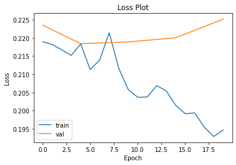

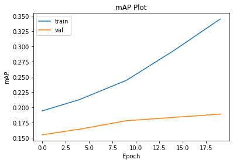

```python
# Compare train and validation metrics
plot_losses(train_losses, val_losses, test_frequency, num_epochs)
plot_mAP(train_mAPs, val_mAPs, test_frequency, num_epochs)
```

```python
# Save the clssifier network
# Suggestion: you can save checkpoints of your network during training and reload them later
torch.save(classifier.state_dict(), './voc_simple_classifier_second_snapshot.pth')
```

# Evaluate on test set

```python
ds_test = VocDataset('/content/VOCdevkit_2007/VOC2007test/','test', test_transform)

test_loader = torch.utils.data.DataLoader(dataset=ds_test,
                                               batch_size=50,
                                               shuffle=False,
                                               num_workers=1)

# Transforms applied to the testing data
test_transform = transforms.Compose([
            transforms.Resize(227),
            transforms.CenterCrop(227),
            transforms.ToTensor(),
            normalize,
        ])

mAP_test, test_loss, test_aps = test_classifier(test_loader, classifier, criterion)
```

```
/content/gdrive/My Drive/Colab Notebooks/CS498/assignment3_part1/voc_dataloader.py:137: VisibleDeprecationWarning: Creating an ndarray from ragged nested sequences (which is a list-or-tuple of lists-or-tuples-or ndarrays with different lengths or shapes) is deprecated. If you meant to do this, you m…
  np.array(box_indices),
```

```
-------  Class: aeroplane        AP:   0.3756  -------
-------  Class: bicycle          AP:   0.0899  -------
-------  Class: bird             AP:   0.1156  -------
-------  Class: boat             AP:   0.1806  -------
-------  Class: bottle           AP:   0.1046  -------
-------  Class: bus              AP:   0.0955  -------
-------  Class: car              AP:   0.3599  -------
-------  Class: cat              AP:   0.1443  -------
-------  Class: chair            AP:   0.2473  -------
-------  Class: cow              AP:   0.0557  -------
-------  Class: diningtable      AP:   0.1628  -------
-------  Class: dog              AP:   0.1437  -------
-------  Class: horse            AP:   0.1889  -------
-------  Class: motorbike        AP:   0.1537  -------
-------  Class: person           AP:   0.5561  -------
-------  Class: pottedplant      AP:   0.0916  -------
-------  Class: sheep            AP:   0.0541  -------
-------  Class: sofa             AP:   0.1763  -------
-------  Class: train            AP:   0.2450  -------
-------  Class: tvmonitor        AP:   0.1156  -------
mAP: 0.1828
Avg loss: 0.22210764691233634
```

```python
output_submission_csv('my_solution.csv', test_aps)
```

# AlexNet Baselines (From Scratch)

AlexNet was one of the earliest deep learning models to have success in classification. In this section we will be running classification with AlexNet as a baseline. Furthermore, we will run an ImageNet-pretrained AlexNet to observe the impact of well-trained features. Save plots and final test mAP scores as you will be adding these to the writeup.

## Running AlexNet

In this section, we train AlexNet from scratch using the same hyperparameters as our previous experiment.

```python
num_epochs = 20
test_frequency = 5

# Change classifier to AlexNet
classifier = torchvision.models.alexnet(pretrained=False)
classifier.classifier._modules['6'] = nn.Linear(4096, 21)
classifier = classifier.to(device)

criterion = nn.MultiLabelSoftMarginLoss()

optimizer = torch.optim.SGD(classifier.parameters(), lr=0.01, momentum=0.9)
```

```python
classifier, train_losses, val_losses, train_mAPs, val_mAPs = train(classifier, num_epochs, train_loader, val_loader, criterion, optimizer, test_frequency)
```

```
Starting epoch number 1
Loss for Training on Epoch 1 is 0.568879246711731
-------  Class: aeroplane        AP:   0.1303  -------
-------  Class: bicycle          AP:   0.0437  -------
-------  Class: bird             AP:   0.1063  -------
-------  Class: boat             AP:   0.1155  -------
-------  Class: bottle           AP:   0.0393  -------
-------  Class: bus              AP:   0.0287  -------
-------  Class: car              AP:   0.1135  -------
-------  Class: cat              AP:   0.0970  -------
-------  Class: chair            AP:   0.1104  -------
-------  Class: cow              AP:   0.0354  -------
-------  Class: diningtable      AP:   0.0481  -------
-------  Class: dog              AP:   0.1147  -------
-------  Class: horse            AP:   0.0467  -------
-------  Class: motorbike        AP:   0.0350  -------
-------  Class: person           AP:   0.4247  -------
-------  Class: pottedplant      AP:   0.0426  -------
-------  Class: sheep            AP:   0.0348  -------
-------  Class: sofa             AP:   0.0905  -------
-------  Class: train            AP:   0.0393  -------
-------  Class: tvmonitor        AP:   0.0476  -------
mAP: 0.0872
Avg loss: 0.28787120066437066
Evaluating classifier
Mean Precision Score for Testing on Epoch 1 is 0.08719491091206401
Starting epoch number 2
Loss for Training on Epoch 2 is 0.256493479013443
Starting epoch number 3
Loss for Training on Epoch 3 is 0.24473805725574493
Starting epoch number 4
Loss for Training on Epoch 4 is 0.25303709506988525
Starting epoch number 5
Loss for Training on Epoch 5 is 0.2492648959159851
-------  Class: aeroplane        AP:   0.1000  -------
-------  Class: bicycle          AP:   0.0449  -------
-------  Class: bird             AP:   0.1108  -------
-------  Class: boat             AP:   0.1011  -------
-------  Class: bottle           AP:   0.0417  -------
-------  Class: bus              AP:   0.0290  -------
```

[output cut: 105 more lines]

```
-------  Class: cow              AP:   0.0376  -------
-------  Class: diningtable      AP:   0.0670  -------
-------  Class: dog              AP:   0.1207  -------
-------  Class: horse            AP:   0.0563  -------
-------  Class: motorbike        AP:   0.0451  -------
-------  Class: person           AP:   0.5077  -------
-------  Class: pottedplant      AP:   0.0562  -------
-------  Class: sheep            AP:   0.0447  -------
-------  Class: sofa             AP:   0.1003  -------
-------  Class: train            AP:   0.0516  -------
-------  Class: tvmonitor        AP:   0.0533  -------
mAP: 0.0997
Avg loss: 0.2355448326059416
Evaluating classifier
Mean Precision Score for Testing on Epoch 20 is 0.09968264794874682
```

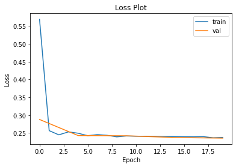

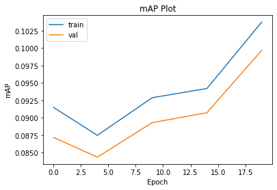

```python
plot_losses(train_losses, val_losses, test_frequency, num_epochs)
plot_mAP(train_mAPs, val_mAPs, test_frequency, num_epochs)
```

```python
mAP_test, test_loss, test_aps = test_classifier(test_loader, classifier, criterion)
print("Test mAP: ", mAP_test)
```

```
-------  Class: aeroplane        AP:   0.0701  -------
-------  Class: bicycle          AP:   0.0567  -------
-------  Class: bird             AP:   0.1037  -------
-------  Class: boat             AP:   0.0663  -------
-------  Class: bottle           AP:   0.0472  -------
-------  Class: bus              AP:   0.0331  -------
-------  Class: car              AP:   0.1483  -------
-------  Class: cat              AP:   0.0910  -------
-------  Class: chair            AP:   0.1422  -------
-------  Class: cow              AP:   0.0424  -------
-------  Class: diningtable      AP:   0.0559  -------
-------  Class: dog              AP:   0.1251  -------
-------  Class: horse            AP:   0.0530  -------
-------  Class: motorbike        AP:   0.0410  -------
-------  Class: person           AP:   0.5113  -------
-------  Class: pottedplant      AP:   0.0506  -------
-------  Class: sheep            AP:   0.0561  -------
-------  Class: sofa             AP:   0.1040  -------
-------  Class: train            AP:   0.0567  -------
-------  Class: tvmonitor        AP:   0.0506  -------
mAP: 0.0953
Avg loss: 0.23101707562804222
Test mAP:  0.0952642134369259
```

```python
torch.save(classifier.state_dict(), './voc_alexnet_nopretrain_sgd_snapshot.pth')
```

You should notice somewhat poor performance. You could try running AlexNet with an Adam optimizer instead with learning rate 1e-4 to see if that makes a difference. This experiment is not required for the writeup, but it may show you the importance of a good learning rate and optimizer.

## Pretrained AlexNet

Here we look at the impact of pretrained features. This model's weights were trained on ImageNet, which is a much larger dataset. How do pretrained features perform on VOC? Why do you think there is such a large difference in performance?

```python
num_epochs = 20
test_frequency = 5

# Load Pretrained AlexNet
classifier = torchvision.models.alexnet(pretrained=True)
classifier.classifier._modules['6'] = nn.Linear(4096, 21)
classifier = classifier.to(device)
optimizer = torch.optim.SGD(classifier.parameters(), lr=0.01, momentum=0.9)
```

```
Downloading: "https://download.pytorch.org/models/alexnet-owt-4df8aa71.pth" to /root/.cache/torch/hub/checkpoints/alexnet-owt-4df8aa71.pth
```

```python
classifier, train_losses, val_losses, train_mAPs, val_mAPs = train(classifier, num_epochs, train_loader, val_loader, criterion, optimizer, test_frequency)
```

```
Starting epoch number 1
Loss for Training on Epoch 1 is 0.22023361921310425
-------  Class: aeroplane        AP:   0.7606  -------
-------  Class: bicycle          AP:   0.5672  -------
-------  Class: bird             AP:   0.8227  -------
-------  Class: boat             AP:   0.5780  -------
-------  Class: bottle           AP:   0.2416  -------
-------  Class: bus              AP:   0.4681  -------
-------  Class: car              AP:   0.7683  -------
-------  Class: cat              AP:   0.7022  -------
-------  Class: chair            AP:   0.5968  -------
-------  Class: cow              AP:   0.3335  -------
-------  Class: diningtable      AP:   0.4584  -------
-------  Class: dog              AP:   0.6210  -------
-------  Class: horse            AP:   0.6281  -------
-------  Class: motorbike        AP:   0.6857  -------
-------  Class: person           AP:   0.9056  -------
-------  Class: pottedplant      AP:   0.2989  -------
-------  Class: sheep            AP:   0.3700  -------
-------  Class: sofa             AP:   0.4739  -------
-------  Class: train            AP:   0.7992  -------
-------  Class: tvmonitor        AP:   0.4953  -------
mAP: 0.5787
Avg loss: 0.13574385613787407
Evaluating classifier
Mean Precision Score for Testing on Epoch 1 is 0.5787493317857768
Starting epoch number 2
Loss for Training on Epoch 2 is 0.12033272534608841
Starting epoch number 3
Loss for Training on Epoch 3 is 0.10696016997098923
Starting epoch number 4
Loss for Training on Epoch 4 is 0.11712945997714996
Starting epoch number 5
Loss for Training on Epoch 5 is 0.10024350881576538
-------  Class: aeroplane        AP:   0.8308  -------
-------  Class: bicycle          AP:   0.6977  -------
-------  Class: bird             AP:   0.8463  -------
-------  Class: boat             AP:   0.7517  -------
-------  Class: bottle           AP:   0.3780  -------
-------  Class: bus              AP:   0.5943  -------
```

[output cut: 105 more lines]

```
-------  Class: cow              AP:   0.4983  -------
-------  Class: diningtable      AP:   0.5713  -------
-------  Class: dog              AP:   0.6983  -------
-------  Class: horse            AP:   0.7408  -------
-------  Class: motorbike        AP:   0.7893  -------
-------  Class: person           AP:   0.9079  -------
-------  Class: pottedplant      AP:   0.4462  -------
-------  Class: sheep            AP:   0.5729  -------
-------  Class: sofa             AP:   0.5022  -------
-------  Class: train            AP:   0.8720  -------
-------  Class: tvmonitor        AP:   0.6395  -------
mAP: 0.6748
Avg loss: 0.177303589442197
Evaluating classifier
Mean Precision Score for Testing on Epoch 20 is 0.6747583670497821
```

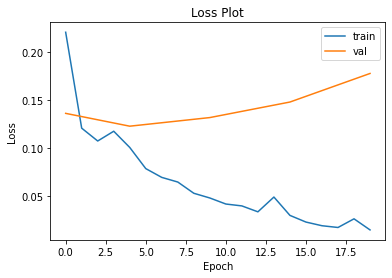

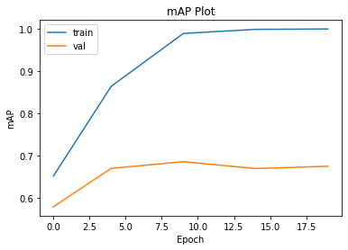

```python
plot_losses(train_losses, val_losses, test_frequency, num_epochs)
plot_mAP(train_mAPs, val_mAPs, test_frequency, num_epochs)
```

```python
mAP_test, test_loss, test_aps = test_classifier(test_loader, classifier, criterion)
print("Test mAP: ", mAP_test)
```

```
-------  Class: aeroplane        AP:   0.8407  -------
-------  Class: bicycle          AP:   0.7365  -------
-------  Class: bird             AP:   0.8266  -------
-------  Class: boat             AP:   0.7798  -------
-------  Class: bottle           AP:   0.3100  -------
-------  Class: bus              AP:   0.6486  -------
-------  Class: car              AP:   0.8379  -------
-------  Class: cat              AP:   0.7912  -------
-------  Class: chair            AP:   0.5717  -------
-------  Class: cow              AP:   0.4741  -------
-------  Class: diningtable      AP:   0.6259  -------
-------  Class: dog              AP:   0.7059  -------
-------  Class: horse            AP:   0.8124  -------
-------  Class: motorbike        AP:   0.7479  -------
-------  Class: person           AP:   0.9186  -------
-------  Class: pottedplant      AP:   0.4485  -------
-------  Class: sheep            AP:   0.5678  -------
-------  Class: sofa             AP:   0.4930  -------
-------  Class: train            AP:   0.8778  -------
-------  Class: tvmonitor        AP:   0.6267  -------
mAP: 0.6821
Avg loss: 0.17180101647973062
Test mAP:  0.6820689574466966
```

```python
torch.save(classifier.state_dict(), './voc_alexnet_pretrain_sgd_snapshot.pth')
```